# Salience analysis

Junhui Park

2026-09-27

## Purpose

This file measures the salience of the CCC in parliamentary climate-policy debates.

## Analytical scope

Two forms of salience are examined: (1) Explicit references to the CCC (2) References to the CCC policy themes

## Corpus

The analysis uses the climate-policy corpus constructed in 1_full corpus building.Rmd. The climate-policy corpus contains 21,776 speeches and is based on word-boundary keyword matching.

## Analytical strategy

Salience is measured as the proportion of climate-policy speeches containing: - explicit CCC references, or - CCC policy-theme references. Salience is examined at two levels: - period level (pre, transition, post), - yearly level (2017-2022).

## Important decisions

- Word-boundary matching is used throughout the analysis.
- The original CCC policy-theme dictionary is used for the main analysis.
- The stricter dictionary specification is reserved for robustness checks.

## Workflow note

This document measures the salience of explicit CCC references and CCC-related policy themes in parliamentary climate-policy speeches. It reconstructs the relevant corpus and dictionaries, compares counts and proportions across periods and years, and produces the corresponding visualisations. Explicit institutional references and broader thematic references are distinct indicators; changes in the latter cannot, by themselves, be attributed causally to the CCC. The code is unchanged and the notes do not imply that the analysis has been re-run.

# Data loading

```r
# Read the parliamentary source files into R. The resulting objects provide the input for the extraction and filtering steps below.

all_files <- list.files("xml_folder_path",
                    pattern = "\\.xml$",
                    full.names = TRUE)

length(all_files)
head(all_files, 5)

test_file <- all_files[1]
test_file
```

# Parsing

```r
# Extract speech text and relevant metadata from the XML structure, applying the cleaning operations specified in the code. Subsequent counts depend on the unit of text produced here.

parse_one_xml <- function(file_path) {
 doc <- read_xml(file_path)
 xml_ns_strip(doc)

 if (length(xml_find_all(doc, ".//paragraphe")) > 0) {
  nodes <- xml_find_all(doc, ".//paragraphe")
  tag_used <- "paragraphe"
 } else if (length(xml_find_all(doc, ".//para")) > 0) {
  nodes <- xml_find_all(doc, ".//para")
  tag_used <- "para"
 } else if (length(xml_find_all(doc, ".//texte")) > 0) {
  nodes <- xml_find_all(doc, ".//texte")
  tag_used <- "texte"
 } else {
  return(tibble(
         file = basename(file_path),
         tag_used = NA_character_,
         speech_text = NA_character_
         ))
 }

tibble(
 file = basename(file_path),
 tag_used = tag_used,
 speech_text = xml_text(nodes)
) %>%
 mutate(
  speech_text = str_remove_all(speech_text, "\\d+"),
  speech_text = str_remove_all(speech_text, "\\([^\\)]+\\)"),
  speech_text = str_remove_all(speech_text, "La parole est à.*?(\\.|$)"),
  speech_text = str_remove_all(speech_text, "La séance est.*?(\\.|$)"),
  speech_text = str_squish(speech_text)
 ) %>%
 filter(!is.na(speech_text), speech_text != "")
}
```

# Full corpus building

```r
# Construct or inspect the working speech corpus and its analytical subsets.

df_full <- map_dfr(all_files, parse_one_xml)

dim(df_full)
head(df_full, 10)
table(df_full$tag_used, useNA = "ifany")

df_full <- df_full %>%
 filter(!is.na(speech_text), speech_text != "")
```

# Temporal variables

```r
# Derive the year and analytical period used in subsequent comparisons. The transition year is treated separately where specified in the code.

df_full <- df_full %>%
 mutate(
  year = stringr::str_extract(file, "20\\d{2}") %>%
   as.numeric(),
  period = case_when(
   year %in% 2017:2019 ~ "pre",
   year == 2020 ~ "transition",
   year %in% 2021:2022 ~ "post",
   TRUE ~ NA_character_
 )
) %>%
 filter(year %in% 2017:2022)
```

# Climate-policy keywords

```r
# Specify the general climate-policy search terms. These terms delimit the broader debate corpus for the later CCC-related analyses.


climate_keywords <- c(
 "climat", "climatique",
 "environnement", "écologie",
 "transition écologique",
 "transition énergétique",
 "émissions",
 "carbone",
 "pollution",
 "fiscalité carbone",
 "pesticides",
 "déchets",
 "recyclage",
 "passoires énergétiques",
 "neutralité carbone",
 "empreinte carbone",
 "énergies renouvelables",
 "sobriété énergétique",
 "rénovation énergétique",
 "efficacité énergétique",
 "économie circulaire",
 "zéro artificialisation nette",
 "transition juste",
 "report modal",
 "covoiturage",
 "alimentation durable",
 "engrais minéraux azotés",
 "sortie du pétrole"
 )
```

# Climate-policy subset building

Construct the climate-policy corpus using word-boundary keyword matching. This corpus constitutes the analytical basis for all subsequent salience calculations.

```r
# Select speech texts matching the general climate-policy dictionary. This subset supplies the reference population for subsequent proportions.


climate_pattern <- regex(
 paste0("\\b(", paste(climate_keywords, collapse = "|"), ")\\b"), ignore_case = TRUE
)

df_climate <- df_full %>%
 filter(str_detect(speech_text, climate_pattern))

dim(df_climate)
```

```
## [1] 21776     5
```

```r
nrow(df_climate) / nrow(df_full)
```

```
## [1] 0.02960059
```

```r
df_climate %>%
 count(period) %>%
 mutate(ratio = n / sum(n))
```

```
## # A tibble: 3 × 3
##   period         n ratio
##   <chr>      <int> <dbl>
## 1 post        8105 0.372
## 2 pre         9503 0.436
## 3 transition  4168 0.191
```

# Sample texts inspection

```r
# Inspect selected matched speeches to assess whether the dictionary captures substantively relevant uses and to identify potential false positives.

set.seed(123)

sample_climate_policy <- df_climate %>%
 slice_sample(n = min(5, nrow(df_climate))) %>%
 mutate(id = row_number())

textfile <- capture.output({
for(i in seq_len(nrow(sample_climate_policy))) {
 cat("\n\n=====================\n")
 cat("ID:", sample_climate_policy$id[i],"\n")
 cat("YEAR:", sample_climate_policy$year[i],"\n")
 cat("PERIOD:", sample_climate_policy$period[i], "\n\n")
 cat(sample_climate_policy$speech_text[i])
 cat("\n")
 }
})

writeLines(textfile, "rev_climate_policy_manual_inspection.txt")
```

# Checking matched keywords

```r
# Define, combine or inspect the keyword set used in the subsequent matching step. Keyword selection determines the breadth of the resulting indicator.

sample_text <- sample_climate_policy %>%
 filter(id == 5) %>%
 pull(speech_text)

matches <- sapply(climate_keywords, function(keyword) {
 str_detect(sample_text, fixed(keyword, ignore_case = TRUE))
})

matched_phrases <- climate_keywords[matches]

matched_phrases

data.frame(
 keyword = climate_keywords,
 matched = matches
) %>%
 filter(matched == TRUE)
```

# Explicit CCC dictionary

Identify speeches containing explicit references to the CCC. The dictionary captures direct references to the Convention.

```r
# Define, combine or inspect the keyword set used in the subsequent matching step. Keyword selection determines the breadth of the resulting indicator.


ccc_explicit <- c(
 "convention citoyenne",
 "convention citoyenne pour le climat",
 "convention citoyenne sur le climat",
 "conventions citoyennes",
 "citoyens de la convention",
 "citoyens tirés au sort",
 "150 citoyens"
 )
```

# Explicit CCC subset building

```r
# Identify speeches containing explicit CCC reference terms and retain the relevant matching information for later checks or comparisons.


explicit_ccc_pattern <- regex(
 paste0(
  "\\b(",
  paste(ccc_explicit, collapse = "|"),
  ")\\b"
 ),
 ignore_case = TRUE
)

df_ccc_explicit <- df_climate %>%
 filter(
  str_detect(
   speech_text,
   explicit_ccc_pattern
  )
 )

dim(df_ccc_explicit)
```

```
## [1] 655   5
```

```r
nrow(df_ccc_explicit) / nrow(df_climate)
```

```
## [1] 0.03007899
```

```r
table(df_ccc_explicit$period, useNA = "ifany")
```

```
##
##       post        pre transition
##        480         17        158
```

```r
df_ccc_explicit %>%
 count(period) %>%
 mutate(ratio = n / sum(n))
```

```
## # A tibble: 3 × 3
##   period         n  ratio
##   <chr>      <int>  <dbl>
## 1 post         480 0.733
## 2 pre           17 0.0260
## 3 transition   158 0.241
```

# Salience comparison check

```r
# Inspect intermediate results for coverage, plausible matches and potential noise. This is a diagnostic step rather than a separate inferential test.

df_ccc_explicit %>%
 count(period) %>%
 left_join(df_climate %>% count(period), by = "period",
           suffix = c("_ccc_explicit", "_climate")) %>%
 mutate(ratio = round(n_ccc_explicit / n_climate, 3),
        proportion = round(n_ccc_explicit / n_climate * 100, 2))
```

```
## # A tibble: 3 × 5
##   period     n_ccc_explicit n_climate ratio proportion
##   <chr>               <int>     <int> <dbl>      <dbl>
## 1 post                  480      8105 0.059       5.92
## 2 pre                    17      9503 0.002       0.18
## 3 transition            158      4168 0.038       3.79
```

# Explicit CCC results check

```r
# Inspect intermediate results for coverage, plausible matches and potential noise. This is a diagnostic step rather than a separate inferential test.

set.seed(123)

sample_ccc_explicit <- df_ccc_explicit %>%
 slice_sample(n = min(10, nrow(df_ccc_explicit))) %>%
 mutate(id = row_number())

textfile <- capture.output({
for(i in seq_len(nrow(sample_ccc_explicit))) {
 cat("\n\n=====================\n")
 cat("ID:", sample_ccc_explicit$id[i],"\n")
 cat("YEAR:", sample_ccc_explicit$year[i],"\n")
 cat("PERIOD:", sample_ccc_explicit$period[i], "\n\n")
 cat(sample_ccc_explicit$speech_text[i])
 cat("\n")
 }
})

writeLines(textfile, "rev_ccc_explicit_manual_inspection.txt")
```

# CCC policy cluster keywords

Identify speeches containing references to policy themes associated with the CCC. The dictionary is organised into six thematic clusters derived from the CCC final report.

## (1) consumption

```r
# Define or inspect the consumption-cluster keyword set. The subsequent matching step treats these terms as indicators of thematic overlap, not proof of an explicit CCC reference.

consumption <- c(
  "surconsommation",
  "emballage",
  "plastique à usage unique",
  "publicité",
  "suremballage",
  "consommation responsable",
  "affichage environnemental",
  "affichage carbone",
  "écoresponsables",
  "écoresponsabilité",
  "produits polluants",
  "produits vertueux",
  "recyclage",
  "économie circulaire",
  "déchets d'emballage",
  "utilisation du plastique",
  "vrac",
  "réutilisable",
  "contenants réutilisables",
  "bouteilles plastiques",
  "réduction des déchets",
  "matériaux biodégradables",
  "réemploi"
)
```

# CCC policy cluster keywords

## (2) Production and Work

```r
# Define or inspect production-and-work terms in the policy-theme dictionary. Review broad terms for context-dependent matches.

production_work <- c(
  "produits durables",
  "écoconception",
  "longévité des produits",
  "investissements verts",
  "clauses environnementales",
  "droit pollueur-payeur",
  "filières émettrices",
  "écocide",
  "produits micropolluants",
  "énergie verte",
  "énergies renouvelables",
  "méthanisation",
  "autoconsommation",
  "écolabels",
  "énergie décarbonée"
)
```

# CCC policy cluster keywords

## (3) Transport and Mobility

```r
# Define or inspect the transport-and-mobility keyword set used to identify relevant speech texts.

transport_mobility <- c(
  "mobilité durable",
  "véhicules faibles émissions",
  "mobilités douces",
  "véhicules partagés",
  "mobilités alternatives",
  "zones de faible émission",
  "pistes cyclables",
  "véhicules électriques",
  "véhicules hybrides",
  "émissions du véhicule",
  "écoconduite",
  "multimodalité",
  "moteur éthanol",
  "moteur électrique",
  "moteur thermique",
  "covoiturage",
  "biocarburants"
)
```

# CCC policy cluster keywords

## (4) Housing

```r
# Define or inspect housing-related keywords and their matching coverage.

housing <- c(
  "construction bas carbone",
  "performance énergétique",
  "rénovation globale",
  "chaudières au fioul",
  "passoires énergétiques",
  "bâtiments énergivores",
  "audit énergétique",
  "certificats d'économies d'énergie",
  "déperditions de chaleur",
  "climatisation",
  "chauffage au fioul"
)
```

# CCC policy cluster keywords

## (5) Food

```r
# Define or inspect the food-policy cluster terms used in the thematic matching procedure.

food <- c(
  "alimentaire durable",
  "EGalim",
  "repas végétariens",
  "restauration collective",
  "faible coût environnemental",
  "transition vers le bio",
  "gaspillage alimentaire",
  "pratiques agroécologiques",
  "agroécologie",
  "réduction des pesticides",
  "agriculture biologique",
  "plan protéagineux",
  "prairies permanentes",
  "reconversion de l'élevage",
  "développement des légumineuses",
  "rediversifier les cultures",
  "engrais chimiques",
  "couvert végétal",
  "élevages de ruminants",
  "ecoscheme",
  "pêche durable",
  "surpêche",
  "propulsion verte",
  "clauses environnementales",
  "consommation de viande",
  "régime moins carné"
)
```

# CCC policy cluster keywords

## (6) Constitution and Governance

```r
# Define or inspect the constitution-and-governance cluster terms. Interpret its counts in light of the keyword set's narrower coverage.

constitution_gov <- c(
  "crime d'écocide",
  "érosion de la biodiversité",
  "utilisation des sols",
  "pollution chimique",
  "dommage écologique",
  "préjudice écologique"
)
```

# Merging CCC policy-theme keywords

```r
# The keywords by cluster were merged into a single data frame to streamline to streamline the data wrangling process.

ccc_policy <- c(
 consumption,
 production_work,
 transport_mobility,
 housing,
 food,
 constitution_gov
)
ccc_policy <- unique(ccc_policy)
```

# CCC policy-theme subset building

```r
# Identify speeches containing one or more CCC policy-theme terms. Such matches indicate thematic overlap and do not necessarily mention the CCC.

ccc_policy_pattern <- regex(
 paste0(
  "\\b(",
  paste(ccc_policy, collapse = "|"),
  ")\\b"),
ignore_case = TRUE)

df_ccc_policy <- df_climate %>%
 filter(
  str_detect(
   speech_text,
   ccc_policy_pattern
  )
 )


dim(df_ccc_policy)
```

```
## [1] 4437    5
```

```r
nrow(df_ccc_policy) / nrow(df_climate)
```

```
## [1] 0.2037564
```

```r
table(df_ccc_policy$period)
```

```
##
##       post        pre transition
##       1669       1699       1069
```

# Salience comparison

```r
# Compare the sizes or proportions of the relevant subsets as specified in the code. Interpret the figures using the denominators actually used here.

df_ccc_policy %>%
 count(period) %>%
 left_join(df_climate %>% count(period), by = "period",
           suffix = c("_ccc_policy", "_climate")) %>%
 mutate(ratio = round(n_ccc_policy / n_climate, 2),
        proportion = round(n_ccc_policy / n_climate * 100, 2))
```

```
## # A tibble: 3 × 5
##   period     n_ccc_policy n_climate ratio proportion
##   <chr>             <int>     <int> <dbl>      <dbl>
## 1 post               1669      8105  0.21       20.6
## 2 pre                1699      9503  0.18       17.9
## 3 transition         1069      4168  0.26       25.6
```

# Manual texts inspection

```r
# Inspect intermediate results for coverage, plausible matches and potential noise. This is a diagnostic step rather than a separate inferential test.


set.seed(5678)

sample_ccc_policy <- df_ccc_policy %>%
 group_by(period) %>%
 slice_sample(n = 10) %>%
 ungroup() %>%
 arrange(period) %>%
 mutate(id = row_number())

textfile <- capture.output({
for(i in seq_len(nrow(sample_ccc_policy))) {
 cat("\n\n=====================\n")
 cat("ID:", sample_ccc_policy$id[i],"\n")
 cat("YEAR:", sample_ccc_policy$year[i],"\n")
 cat("PERIOD:", sample_ccc_policy$period[i], "\n\n")
 cat(sample_ccc_policy$speech_text[i])
 cat("\n")
 }
})

writeLines(textfile, "rev2_ccc_policy_manual_inspection.txt")
```

# Checking matched phrase

```r
# Inspect intermediate results for coverage, plausible matches and potential noise. This is a diagnostic step rather than a separate inferential test.

sample_text <- sample_ccc_policy %>%
 filter(id == 10) %>%
 pull(speech_text)

matches <- sapply(ccc_policy, function(keyword) {
 str_detect(sample_text, fixed(keyword, ignore_case = TRUE))
})

matched_phrases <- ccc_policy[matches]

matched_phrases

data.frame(
 keyword = ccc_policy,
 matched = matches
) %>%
 filter(matched == TRUE)
```

# Corpus size

```r
# Report corpus and subset sizes used as denominators or contextual information for the salience estimates.

corpus_size_yearly <- df_ccc_policy %>%
 mutate(
  n_words = str_count(speech_text, "\\S+")
 ) %>%
 group_by(year) %>%
 summarise(
  speeches = n(),
  total_words = sum(n_words),
  .groups = "drop"
 )

corpus_size_yearly
```

```
## # A tibble: 6 × 3
##    year speeches total_words
##   <dbl>    <int>       <int>
## 1  2017       16        4574
## 2  2018      594      244861
## 3  2019     1089      398193
## 4  2020     1069      268329
## 5  2021     1098      352062
## 6  2022      571      220918
```

# Salience analysis

Calculate salience as the proportion of climate-policy speeches containing CCC-related references. Salience is examined by period and year.

```r
# Calculate the overall and time-specific salience indicators for explicit CCC references and CCC-related policy themes.


# Overall salience increase

## Explicit CCC references
ccc_explicit_salience <- df_ccc_explicit %>%
 mutate(
  period = factor(
   period,
   levels = c("pre", "transition", "post"))
 ) %>%
 count(period) %>%
 left_join(df_climate %>% count(period), by = "period",
           suffix = c("_ccc_explicit", "_climate")) %>%
 mutate(ratio = n_ccc_explicit / n_climate,
        proportion = round(ratio * 100, 2))

ccc_explicit_salience
```

```
## # A tibble: 3 × 5
##   period     n_ccc_explicit n_climate   ratio proportion
##   <chr>               <int>     <int>   <dbl>      <dbl>
## 1 pre                    17      9503 0.00179       0.18
## 2 transition            158      4168 0.0379        3.79
## 3 post                  480      8105 0.0592        5.92
```

```r
write.xlsx(ccc_explicit_salience, "ccc_explicit_salience.xlsx")


## CCC policy-theme references
ccc_policy_salience <- df_ccc_policy %>%
 mutate(
  period = factor(
   period,
   levels = c("pre", "transition", "post"))
 ) %>%
 count(period) %>%
 left_join(df_climate %>% count(period), by = "period",
           suffix = c("_ccc_policy", "_climate")) %>%
 mutate(ratio = n_ccc_policy / n_climate,
        proportion = round(ratio * 100, 2))

ccc_policy_salience
```

```
## # A tibble: 3 × 5
##   period     n_ccc_policy n_climate ratio proportion
##   <chr>             <int>     <int> <dbl>      <dbl>
## 1 pre                1699      9503 0.179       17.9
## 2 transition         1069      4168 0.256       25.6
## 3 post               1669      8105 0.206       20.6
```

```r
write.xlsx(ccc_policy_salience, "ccc_policy_salience.xlsx")

# Across-time development

## explicit CCC
ccc_explicit_yearly <- df_climate %>%
 count(year, name = "n_climate") %>%
 complete(year = 2017:2022, fill = list(n_climate = 0)) %>%
 left_join(df_ccc_explicit %>% count(year, name = "n_ccc_explicit"),
           by = "year"
           ) %>%
 mutate(
  n_ccc_explicit = replace_na(n_ccc_explicit, 0),
  ratio = n_ccc_explicit / n_climate,
        proportion = round(ratio * 100, 2))

ccc_explicit_yearly
```

```
## # A tibble: 6 × 5
##    year n_climate n_ccc_explicit   ratio proportion
##   <dbl>     <int>          <int>   <dbl>      <dbl>
## 1  2017       229              0 0             0
## 2  2018      3739              0 0             0
## 3  2019      5535             17 0.00307       0.31
## 4  2020      4168            158 0.0379        3.79
## 5  2021      5560            439 0.0790        7.9
## 6  2022      2545             41 0.0161        1.61
```

```r
write.xlsx(ccc_explicit_yearly, "ccc_explicit_yearly.xlsx")

## CCC policy-theme
ccc_policy_yearly <- df_climate %>%
 count(year, name = "n_climate") %>%
 complete(year = 2017:2022, fill = list(n_climate = 0)) %>%
 left_join(
  df_ccc_policy %>%
   count(year, name = "n_ccc_policy"),
  by = "year"
 ) %>%
 mutate(
  n_ccc_policy = replace_na(n_ccc_policy, 0),
  ratio = n_ccc_policy / n_climate,
        proportion = round(ratio * 100, 2))

ccc_policy_yearly
```

```
## # A tibble: 6 × 5
##    year n_climate n_ccc_policy  ratio proportion
##   <dbl>     <int>        <int>  <dbl>      <dbl>
## 1  2017       229           16 0.0699       6.99
## 2  2018      3739          594 0.159       15.9
## 3  2019      5535         1089 0.197       19.7
## 4  2020      4168         1069 0.256       25.6
## 5  2021      5560         1098 0.197       19.8
## 6  2022      2545          571 0.224       22.4
```

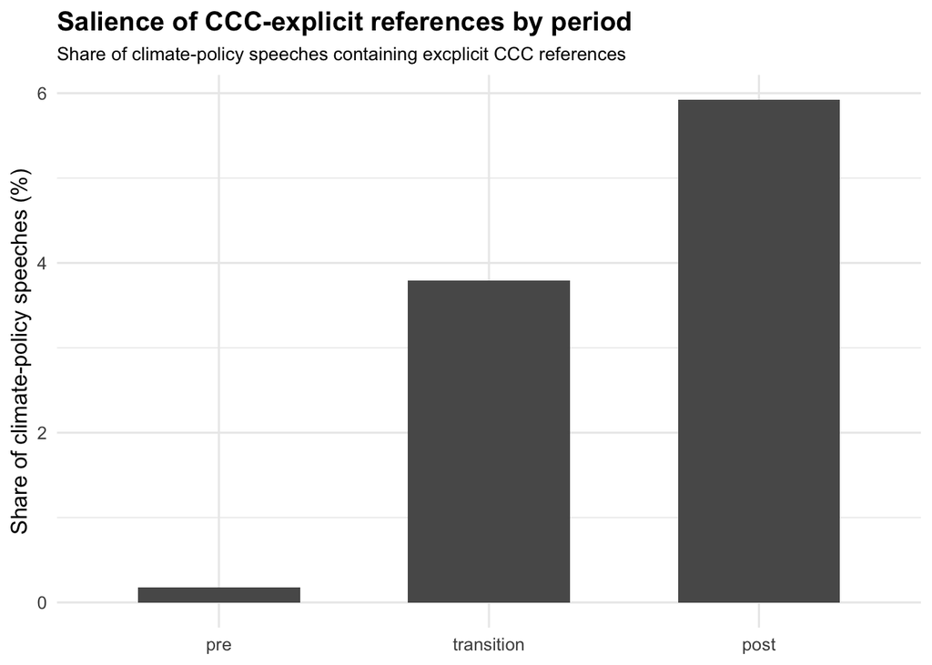

```r
write.xlsx(ccc_policy_yearly, "ccc_policy_yearly.xlsx")

# visualisation

## explicit ccc (periodisation)
ccc_explicit_salience_period <- ccc_explicit_salience %>%
 mutate(
  period = factor(period,
                  levels = c("pre", "transition", "post"))
 ) %>%
  ggplot(aes(x = period, y = proportion)) +
  geom_col(width = 0.6) +
  labs(
    title = "Salience of CCC-explicit references by period",
    subtitle = "Share of climate-policy speeches containing excplicit CCC references",
    x     = NULL,
    y     = "Share of climate-policy speeches (%)"
  ) +
  theme_minimal(base_size = 12) +
  theme(
   plot.title = element_text(face = "bold"),
   plot.subtitle = element_text(size = 10))

ccc_explicit_salience_period
```

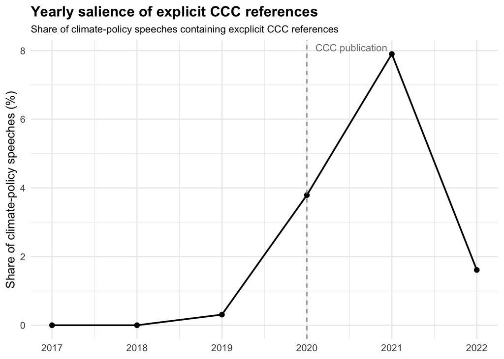

```r
ggsave("ccc_explicit_salience_period.png", ccc_explicit_salience_period, width = 10, height = 6, dpi = 300)

## explicit CCC (yearly)
ccc_explicit_yearly_salience <- ccc_explicit_yearly %>%
  ggplot(aes(x = year, y = proportion)) +
  geom_line(linewidth = 0.8) +
  geom_point(size = 2) +
  geom_vline(xintercept = 2020, linetype = "dashed", colour = "grey50") +
  annotate("text", x = 2020.1, y = Inf, label = "CCC publication",
           hjust = 0, vjust = 1.5, size = 3.5, colour = "grey50") +
  scale_x_continuous(breaks = 2017:2022) +
  labs(
    title = "Yearly salience of explicit CCC references",
    subtitle = "Share of climate-policy speeches containing excplicit CCC references",
    x     = NULL,
    y     = "Share of climate-policy speeches (%)"
  ) +
  theme_minimal(base_size = 12) +
  theme(legend.position = "none",
        plot.title = element_text(face = "bold"),
        plot.subtitle = element_text(size = 10))

ccc_explicit_yearly_salience
```

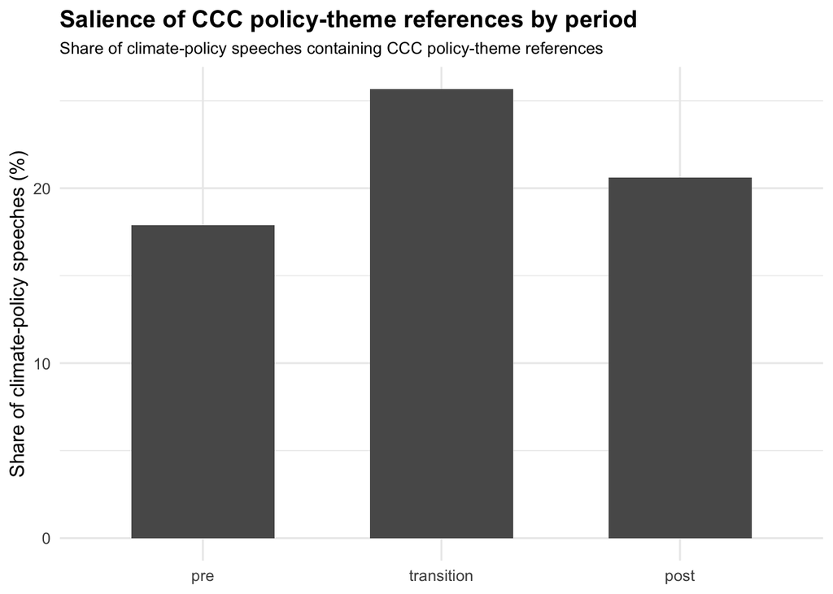

```r
ggsave("ccc_explicit_yearly_salience.png", ccc_explicit_yearly_salience, width = 10, height = 6, dpi = 300)

## CCC policy-theme (periodisation)
ccc_policy_salience_period <- ccc_policy_salience %>%
 mutate(
  period = factor(period,
                  levels = c("pre", "transition", "post"))
 ) %>%
  ggplot(aes(x = period, y = proportion)) +
  geom_col(width = 0.6) +
  labs(
    title = "Salience of CCC policy-theme references by period",
    subtitle = "Share of climate-policy speeches containing CCC policy-theme references",
    x     = NULL,
    y     = "Share of climate-policy speeches (%)"
  ) +
  theme_minimal(base_size = 12) +
  theme(
   plot.title = element_text(face = "bold"),
   plot.subtitle = element_text(size = 10))

ccc_policy_salience_period
```

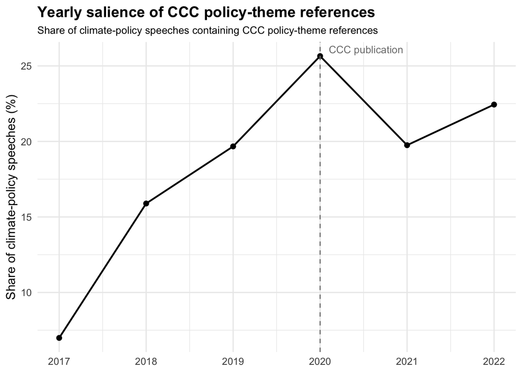

```r
ggsave("ccc_policy_salience_period.png", ccc_policy_salience_period, width = 10, height = 6, dpi = 300)


## CCC policy-theme (yearly)
ccc_policy_yearly_salience <- ccc_policy_yearly %>%
  ggplot(aes(x = year, y = proportion)) +
  geom_line(linewidth = 0.8) +
  geom_point(size = 2) +
  geom_vline(xintercept = 2020, linetype = "dashed", colour = "grey50") +
  annotate("text", x = 2020.1, y = Inf, label = "CCC publication",
           hjust = 0, vjust = 1.5, size = 3.5, colour = "grey50") +
  scale_x_continuous(breaks = 2017:2022) +
  labs(
    title = "Yearly salience of CCC policy-theme references",
    subtitle = "Share of climate-policy speeches containing CCC policy-theme references",
    x     = NULL,
    y     = "Share of climate-policy speeches (%)"
  ) +
  theme_minimal(base_size = 12) +
  theme(legend.position = "none",
        plot.title = element_text(face = "bold"),
        plot.subtitle = element_text(size = 10))

ccc_policy_yearly_salience
```

```r
ggsave("ccc_policy_yearly_salience.png", ccc_policy_yearly_salience, width = 10, height = 6, dpi = 300)
```